### Escolha o Idioma:

🇧🇷 Português 🇺🇸 English

# Análise de Dados: Laboratório Educativo

Bem-vindo ao laboratório de Análise de Dados! Neste projeto educativo quero explorar junto a vocês conceitos que formam a base da manipulação e análise de dados. Esse projeto é baseado no curso [Data Analysis with Python](https://www.coursera.org/learn/data-analysis-with-python) da plataforma Coursera. O tema aqui abordado diz respeito à segunda semana do curso, e é uma realização prática dos conceitos com um conjunto de dados colhido da plataforma Kaggle: [Student Mental health](https://www.kaggle.com/datasets/shariful07/student-mental-health)

Ao final deste projeto, teremos adquirido habilidades essenciais para lidar com dados ausentes, ajustar tipos de dados conforme necessário, padronizar e normalizar atributos relevantes, visualizar dados por meio de gráficos de barras agrupadas usando binning e converter dados categóricos em variáveis indicadoras numéricas.

Agradeço sinceramente à Coursera por proporcionar não apenas uma plataforma educativa abrangente e acessível, mas também por oferecer suporte financeiro (financial aid) que possibilita a prática de diversos cursos. Expresso minha profunda gratidão à comunidade, cujo compartilhamento de conhecimento e apoio mútuo enriquece significativamente a experiência de aprendizado para todos.

## 1. Lidar com Dados Ausentes

Uma análise de dados robusta requer a capacidade de lidar eficazmente com dados ausentes. Existem diversas abordagens para esse desafio, desde a exclusão de entradas incompletas até a imputação de valores faltantes. Vamos explorar essas técnicas, destacando suas aplicações e considerações práticas.

## 2. Correção de Tipos de Dados

A consistência nos tipos de dados é fundamental. Neste laboratório, aprenderemos a identificar e corrigir tipos de dados inadequados, garantindo que cada variável seja interpretada corretamente. Isso é fundamental para evitar erros de análise e interpretação equivocada dos dados.

## 3. Padronização e Normalização

Padronizar e normalizar dados são passos essenciais para comparar atributos em diferentes escalas. Vamos entender a diferença entre esses processos e quando aplicar cada um. Ao final, teremos dados prontos para análises mais precisas e significativas.

## 4. Visualização com Gráficos de Barras Agrupadas (Binning)

A visualização é uma ferramenta poderosa na análise de dados. Abordaremos a técnica de binning, que agrupa dados em intervalos, permitindo uma representação mais clara e interpretável. Prepare-se para criar gráficos de barras agrupadas que revelarão padrões e tendências em seus conjuntos de dados.

## 5. Conversão de Dados Categóricos

Nem sempre os algoritmos podem lidar diretamente com dados categóricos. Aprenderemos a converter essas variáveis em indicadores numéricos, tornando-as compatíveis com uma ampla gama de técnicas analíticas. Este passo é vital para garantir que todos os aspectos do seu conjunto de dados contribuam para análises robustas.

## 6. Considerações finais

## 7. Apêndice

Enfatizamos sumariamente que ao longo deste projeto concentramo-nos não apenas em realizar tarefas, mas em compreender os motivos por trás de cada passo.

# Importando as bibliotecas necessárias

Vamos agora importar as bibliotecas necessárias para dar início ao nosso projeto. Embora a explicação detalhada sobre essa etapa não esteja incluída neste trabalho, é importante compreender que a importação de bibliotecas é uma prática comum na programação em Python. Para aprofundar esse conhecimento, recomendamos explorar recursos online, como a documentação oficial do Python (https://docs.python.org/3/) e tutoriais específicos disponíveis em plataformas de aprendizado, como a própria Coursera ou sites como W3Schools. Essa habilidade será valiosa ao longo do projeto e em futuras explorações na análise de dados.

```python
import numpy as np
import pandas as pd
import matplotlib.pyplot as plt
%matplotlib inline
```

## Leitura do Arquivo CSV

Aqui estamos realizando a leitura do arquivo CSV que está armazenado localmente. O caminho que você está vendo na célula abaixo corresponde à localização do arquivo em **minha máquina**. Para prosseguir e ter acesso ao arquivo em sua máquina, siga os passos abaixo:

1. **Baixe o arquivo:**
   - Visite o link [Student Mental Health](https://www.kaggle.com/datasets/shariful07/student-mental-health) no Kaggle.
   - Baixe o arquivo CSV disponível na página.
2. **Salve o arquivo em sua máquina:**
   - Após o download, salve o arquivo em uma localização acessível em sua máquina.
3. **Atualize o caminho no código:**
   - Caso você tenha salvado o arquivo em um diretório diferente, ajuste o caminho do arquivo no código para refletir a localização correta.

Caso prefira, você também pode utilizar o arquivo que disponibilizei no mesmo diretório do projeto no GitHub. No entanto, baixar o arquivo do Kaggle é recomendado, pois fornece informações adicionais sobre os dados que podem ser úteis. Este procedimento é essencial para garantir que o código funcione corretamente e para que você possa explorar o conjunto de dados de forma eficaz.

```python
# Caminho do arquivo CSV localizado na máquina do autor (substitua pelo seu caminho)
file = r'D:\Jeanco\Meus projetos\students_mental_health\Student Mental health.csv'

# Leitura do arquivo CSV utilizando a biblioteca pandas
df = pd.read_csv(file)

# Visualização do DataFrame para verificar se o arquivo CSV foi lido corretamente
df
```

|  | Timestamp | Choose your gender | Age | What is your course? | Your current year of Study | What is your CGPA? | Marital status | Do you have Depression? | Do you have Anxiety? | Do you have Panic attack? | Did you seek any specialist for a treatment? |
| --- | --- | --- | --- | --- | --- | --- | --- | --- | --- | --- | --- |
| 0 | 8/7/2020 12:02 | Female | 18.0 | Engineering | year 1 | 3.00 - 3.49 | No | Yes | No | Yes | No |
| 1 | 8/7/2020 12:04 | Male | 21.0 | Islamic education | year 2 | 3.00 - 3.49 | No | No | Yes | No | No |
| 2 | 8/7/2020 12:05 | Male | 19.0 | BIT | Year 1 | 3.00 - 3.49 | No | Yes | Yes | Yes | No |
| 3 | 8/7/2020 12:06 | Female | 22.0 | Laws | year 3 | 3.00 - 3.49 | Yes | Yes | No | No | No |
| 4 | 8/7/2020 12:13 | Male | 23.0 | Mathemathics | year 4 | 3.00 - 3.49 | No | No | No | No | No |
| ... | ... | ... | ... | ... | ... | ... | ... | ... | ... | ... | ... |
| 96 | 13/07/2020 19:56:49 | Female | 21.0 | BCS | year 1 | 3.50 - 4.00 | No | No | Yes | No | No |
| 97 | 13/07/2020 21:21:42 | Male | 18.0 | Engineering | Year 2 | 3.00 - 3.49 | No | Yes | Yes | No | No |
| 98 | 13/07/2020 21:22:56 | Female | 19.0 | Nursing | Year 3 | 3.50 - 4.00 | Yes | Yes | No | Yes | No |
| 99 | 13/07/2020 21:23:57 | Female | 23.0 | Pendidikan Islam | year 4 | 3.50 - 4.00 | No | No | No | No | No |
| 100 | 18/07/2020 20:16:21 | Male | 20.0 | Biomedical science | Year 2 | 3.00 - 3.49 | No | No | No | No | No |

101 rows × 11 columns

# Padronização de Nomenclatura de Colunas

Antes de nos aprofundarmos nos tópicos específicos mencionados no início deste projeto, optaremos por adotar convenções de nomenclatura mais consistentes para as colunas do conjunto de dados. Essa prática visa melhorar a legibilidade do código e facilitar a manipulação dos dados, especialmente durante processos de programação. Também colocaremos os nomes em Português do Brasil para facilitar a leitura nesse contexto.

## Convenções Adotadas:

1. **Minúsculas e Sublinhados (Snake Case):**
   - Exemplo: `submission_time`, `choose_your_gender`, `age`, `course`, etc.

## Por que estamos fazendo isso?

Ao adotar essa abordagem, tornamos os nomes das colunas mais amigáveis para programação, facilitando a referência e a manipulação dos dados. Além disso, essa padronização contribui para a consistência no código e na análise, melhorando a clareza e a compreensão do conjunto de dados.

# Exemplo de renomeação de colunas

```
# ... (continuar para as demais colunas)
```

```python
#Renomeando as colunas
df.rename(columns={
    'Timestamp': 'momento_envio',
    'Choose your gender': 'genero',
    'Age': 'idade',
    'What is your course?': 'curso',
    'Your current year of Study': 'ano_estudo_atual',
    'What is your CGPA?': 'cgpa',
    'Marital status': 'estado_civil',
    'Do you have Depression?': 'tem_depressao',
    'Do you have Anxiety?': 'tem_ansiedade',
    'Do you have Panic attack?': 'tem_ataque_panic',
    'Did you seek any specialist for a treatment?': 'buscou_especialista_para_tratamento'
}, inplace=True)

#Verificando as primeiras linhas da tabela
df.head()
```

|  | momento_envio | genero | idade | curso | ano_estudo_atual | cgpa | estado_civil | tem_depressao | tem_ansiedade | tem_ataque_panic | buscou_especialista_para_tratamento |
| --- | --- | --- | --- | --- | --- | --- | --- | --- | --- | --- | --- |
| 0 | 8/7/2020 12:02 | Female | 18.0 | Engineering | year 1 | 3.00 - 3.49 | No | Yes | No | Yes | No |
| 1 | 8/7/2020 12:04 | Male | 21.0 | Islamic education | year 2 | 3.00 - 3.49 | No | No | Yes | No | No |
| 2 | 8/7/2020 12:05 | Male | 19.0 | BIT | Year 1 | 3.00 - 3.49 | No | Yes | Yes | Yes | No |
| 3 | 8/7/2020 12:06 | Female | 22.0 | Laws | year 3 | 3.00 - 3.49 | Yes | Yes | No | No | No |
| 4 | 8/7/2020 12:13 | Male | 23.0 | Mathemathics | year 4 | 3.00 - 3.49 | No | No | No | No | No |

# 1 - Lidar com dados ausentes

**Motivação:**

- Essa análise visa compreender a presença de dados ausentes no conjunto de dados, crucial para análises precisas.
- Em um conjunto de dados mais complexo, identificar e tratar dados ausentes é essencial para análises confiáveis.

**Implicações:**

- Dados ausentes podem impactar a qualidade e validade das análises.
- A compreensão da distribuição de dados ausentes é fundamental para escolher estratégias adequadas de tratamento.

Essa análise foca em garantir que possamos abordar dados ausentes de maneira informada e eficaz.

A seguir analisaremos os dados em busca de "ausências" e proseguiremos com o tratamento e explicação prática da importância de lidarmos com esses vieses.

```python
dados_ausentes = df.isnull()
for coluna in dados_ausentes.columns.values.tolist():
    print(dados_ausentes[coluna].value_counts())
    print("")
df.columns.isnull()
```

```
False    101
Name: momento_envio, dtype: int64

False    101
Name: genero, dtype: int64

False    100
True       1
Name: idade, dtype: int64

False    101
Name: curso, dtype: int64

False    101
Name: ano_estudo_atual, dtype: int64

False    101
Name: cgpa, dtype: int64

False    101
Name: estado_civil, dtype: int64

False    101
Name: tem_depressao, dtype: int64

False    101
Name: tem_ansiedade, dtype: int64

False    101
Name: tem_ataque_panic, dtype: int64

False    101
Name: buscou_especialista_para_tratamento, dtype: int64
```

```
array([False, False, False, False, False, False, False, False, False,
       False, False])
```

Vamos abordar a questão dos dados ausentes, considerando que nosso conjunto de dados é simples, para fins didáticos.

Abaixo está a explicação passo a passo do código utilizado acima para lidar com dados ausentes:

1. **`dados_ausentes = df.isnull()`:**
   - Criamos um DataFrame booleano indicando True para valores ausentes e False para valores presentes em `df`.
2. **`for coluna in dados_ausentes.columns.values.tolist():`:**
   - Iteramos por cada coluna no DataFrame de dados ausentes.
3. **`print(dados_ausentes[coluna].value_counts())`:**
   - Contamos e exibimos a quantidade de valores ausentes (True) e presentes (False) em cada coluna.
4. **`print(df.columns.isnull())`:**
   - Verificamos se há dados ausentes nos rótulos das colunas do DataFrame original, em outras palavras nos indica se algum nome de coluna está vazio. Isso pode ser útil em situações onde há a necessidade de verificar a integridade dos rótulos das colunas no DataFrame.

Agora vamos às explicações para as saídas fornecidas por nosso código. Vejamos um exemplo:

```
momento_envio
False    101
Name: count, dtype: int64
```

Perceba que temos o nome da coluna `momento_envio`. O False representa a quantidade de dados não nulos. Perceba que temos 101 valores não nulos para a coluna em questão.

Agora veja a saída obtida para a coluna `idade`:

```
idade
False    100
True       1
Name: count, dtype: int64
```

- **`False: 100`:** Indica que há 100 valores não nulos na coluna "idade".
- **`True: 1`:** Indica que há um valor nulo (ausente) na coluna "idade".

As demais informações presentes nas saídas não são relevantes para o entendimento no escopo deste projeto.

Mas qual é o valor que está no local do valor nulo na coluna "idade"? Vamos usar o método unique() para obter os valores exclusivos na coluna e descobrir isso.

```python
print(df['idade'].unique())
```

```
[18. 21. 19. 22. 23. 20. 24. nan]
```

A saída acima indica que na coluna idade temos 18 anos, 21 anos e assim por diante. Veja o último valor: nan.

Agora identificamos que nosso valor nulo é representado por "nan" (not a number), permitindo-nos prosseguir com confiança na manipulação desse dado ausente. O uso consistente de "nan" como representação padrão traz benefícios em termos de consistência e compatibilidade em operações numéricas. Não é necessário compreender profundamente esses detalhes; o ponto chave é que o uso de "nan" como valor ausente é preferível a outras representações

Entender que estamos lidando com "nan" nos permite empregar estratégias específicas, como substituição pela média ou pelo valor mais frequente, de maneira eficaz.

**Importância de Saber o Valor no Nulo:**

Conhecer o valor específico que ocupa o lugar do nulo é fundamental para a tomada de decisões informadas sobre como lidar com ele. Por exemplo, se o valor nulo fosse representado por um caractere específico, como "?", seria necessário identificar e tratar esse caractere de maneira única, evitando ambiguidades em operações numéricas e garantindo a coerência nos dados.

Em resumo, a escolha da representação de valor nulo afeta diretamente a maneira como lidamos com esses valores durante a análise de dados, e optar por "nan" proporciona uma abordagem padronizada e eficiente.

## 1.1 - Substituição de valores nulos pela Média

Quando lidamos com atributos que possuem dados contínuos, a abordagem mais adequada para substituir valores ausentes é utilizando a média. No nosso conjunto de dados, a variável "idade" é contínua, representando valores como 18, 21, 19, e assim por diante. Se alguns desses valores estiverem ausentes, podemos preenchê-los com a média da variável.

Dados contínuos referem-se a variáveis que podem assumir qualquer valor dentro de um intervalo específico, como a idade, que pode ser representada por números reais. Em contraste com dados discretos, que assumem valores específicos e geralmente são inteiros, dados contínuos podem incluir frações ou números decimais.

Utilizando o código abaixo, substituímos os valores ausentes na coluna "idade" pela média dessa mesma coluna:

```python
media_idade = df['idade'].astype('float').mean(axis=0)
df['idade'].replace(np.nan, media_idade, inplace=True)
print(df['idade'].unique())
```

```
[18.   21.   19.   22.   23.   20.   24.   20.53]
```

Perceba que agora temos o valor 20.53 em vez de 'nan'. Esse valor é a média de todas as idades apresentadas na coluna.

A estratégia de substituição pela média é adotada para manter a coerência na distribuição dos dados.

## 1.2 - Substituição de valores nulos pelo valor mais Frequente

### Exemplificativo

Quando lidamos com atributos que contêm dados categóricos, a abordagem recomendada para substituir valores ausentes é utilizar o valor mais frequente na categoria. Vamos considerar o cenário em que temos uma coluna categórica, por exemplo, a coluna "estado_civil", e alguns valores estão ausentes. A estratégia apropriada seria substituir esses valores pelo estado civil mais frequente.

Dados categóricos referem-se a variáveis que representam categorias discretas, como "Solteiro", "Casado" ou "Divorciado". Ao depararmos com valores ausentes nesse tipo de atributo, é benéfico preenchê-los com o valor mais comum da categoria, mantendo a integridade da distribuição.

A seguir, apresento um código genérico que exemplifica como substituir, com o valor mais frequente, os valores ausentes na coluna categórica:

```
valor_mais_frequente_estado_civil = df['estado_civil'].value_counts().idxmax()
df['estado_civil'].replace(np.nan, valor_mais_frequente_estado_civil, inplace=True)
```

Essa abordagem garante que os valores ausentes sejam preenchidos de maneira representativa, isso visa manter a coesão na distribuição dos dados categóricos.

# 2 - Correção de tipos de dados

Antes de iniciar, gostaríamos de enfatizar que nossos dados possuem alguns desafios adicionais no momento da conversão e isso é justamente a fim de que possamos visualizar algumas possibilidades e opções de como os dados podem estar em sua forma bruta, ou seja, como eles vêm da fonte. Lembre-se que isso aqui não é um trabalho extensivo que esgota as possibilidades, mas uma visão geral com aplicações de conceitos chave que podem nos ajudar a desenvolver autonomia.

**Motivação:**

- A conversão é uma das etapas a serem seguidas no processo de preparação de dados, garantindo que as variáveis estejam no formato correto para análises subsequentes.
- A escolha de tipos de dados apropriados otimiza o desempenho computacional, facilita operações matemáticas e contribui para uma interpretação mais clara das variáveis.

**Implicações:**

- A falta de conversão pode resultar em inconsistências nos resultados, prejudicando a confiabilidade das análises.
- A padronização dos tipos de dados facilita a interpretação e execução de operações específicas, melhorando a eficácia das análises..

A seguir, exploraremos a conversão de tipos em nosso conjunto de dados, exemplificando com casos práticos e destacando a importância dessa etapa no processo de manipulação e análise.

Vamos analisar cada coluna e determinar a melhor abordagem para corrigir cada tipo:

```python
df.dtypes
```

```
momento_envio                           object
genero                                  object
idade                                  float64
curso                                   object
ano_estudo_atual                        object
cgpa                                    object
estado_civil                            object
tem_depressao                           object
tem_ansiedade                           object
tem_ataque_panic                        object
buscou_especialista_para_tratamento     object
dtype: object
```

O que devemos considerar para corrigir os dados é a forma como eles serão utilizados no problema a ser resolvido, e para esse trabalho faremos algumas considerações gerais sobre como lidar com isso.

Vejamos algumas colunas e possibilidades:

`momento_envio`: Essa coluna deve ser convertida para o tipo de dado de data e hora (datetime), já que representa o momento de envio (data).

Colunas com valores Yes e No (`tem_depressao`, `tem_ansiedade`, `tem_ataque_panic`, `buscou_especialista_para_tratamento`): Se essas colunas representarem variáveis binárias, ou seja, valores 0 e 1 ou verdadeiro e falso; é uma prática comum convertê-las para o tipo de dado booleano (True ou False). Isso pode facilitar operações lógicas e análises futuras. Para nosso trabalho, vamos manter essas colunas como estão.

`ano_estudo_atual`: Parece ser uma variável categórica representando o ano de estudo. Podemos convertê-la para o tipo de dado categórico.

`cgpa`: o termo "CGPA" geralmente se refere à "Cumulative Grade Point Average" em inglês, ou em português, "Média Cumulativa de Notas". O CGPA é uma métrica comumente usada em sistemas educacionais, especialmente em instituições que seguem o sistema de avaliação por notas. Esse valor é uma média ponderada das notas obtidas pelos alunos durante seu período de estudo. Ele reflete o desempenho acadêmico geral do aluno ao longo de um determinado período. Normalmente, as notas são convertidas para uma escala específica, e a média é calculada levando em consideração os créditos ou pesos associados a cada curso.

Ao realizar análises no mundo real, lembre-se de explorar profundamente o conjunto de dados e suas características intrínsecas. Por questões didáticas, nos concentraremos nas explicações mais amplas neste contexto educativo.

```python
df.dtypes
```

```
momento_envio                           object
genero                                  object
idade                                  float64
curso                                   object
ano_estudo_atual                        object
cgpa                                    object
estado_civil                            object
tem_depressao                           object
tem_ansiedade                           object
tem_ataque_panic                        object
buscou_especialista_para_tratamento     object
dtype: object
```

### 2.1 Convertendo a coluna "momento_envio"

Primeiro falaremos sobre casos mais complicados como o que será abordado a seguir, mas em geral o método `astype()` - sobre o qual falaremos mais adiante - é uma maneira comum de converter o tipo de dados de uma coluna. Para um trabalho básico como o nosso, essa explicação é suficiente.

Na coluna `momento_envio`, os dados incluem informações de data e hora. Seja qual for a abordagem adotada, ela precisará lidar com diferentes formatos de data, como dia/mês/ano, mês/ano/dia, com ou sem informações de horas.

Para esse projeto não corrigiremos os dados dessa coluna, extensivamente, pois isso fugiria ao escopo simplificado que buscamos apresentar aqui; no entanto, faremos algumas considerações relevantes e interessantes e apresentaremos, a título exemplificativo, uma conversão. Leia com atenção:

Ao lidar com dados que envolvem datas e horas, adentramos em um território que pode ser cheio de desafios e complexidades. A manipulação desses dados não é tão trivial quanto parece à primeira vista. Aqui estão algumas razões pelas quais dados referentes a datas e horas podem apresentar dificuldades consideráveis em sua manipulação/transformação.

**Formatos Variados**: Datas podem ser apresentadas em diversos formatos, como "dia/mês/ano" ou "ano/mês/dia", e horários podem incluir ou não segundos. A variedade de representações adiciona complexidade ao processo de conversão.

**Dados Ausentes ou Inconsistentes**: Muitas vezes, conjuntos de dados podem conter datas ausentes ou formatadas de maneira inconsistente. Isso pode resultar em erros durante a conversão para um formato padrão.

**Fusos Horários**: Em ambientes globais, a presença de diferentes fusos horários pode complicar ainda mais a interpretação correta das datas e horas, especialmente se essas informações não estiverem claramente definidas.

**Presença de Texto Adicional**: Às vezes, datas e horas podem estar "misturadas" a outros dados de texto, tornando necessário separar e converter essas informações de maneira cuidadosa.

**Precisão e Granularidade**: Dependendo do contexto, pode ser necessário trabalhar com diferentes níveis de precisão temporal, como dias, horas, minutos ou até mesmo segundos. A manipulação precisa desses níveis de granularidade adiciona camadas de complexidade.

É fundamental reconhecer que o processo de transformação de dados como os presentes na coluna `momento_envio` pode ser significativamente desafiador e apresentar diferentes níveis de complexidade. Em situações do mundo real, uma análise abrangente de datas e horas muitas vezes envolve considerações detalhadas e métodos avançados.

Em nosso trabalho atual, estamos focando em conceitos mais básicos para proporcionar uma compreensão sólida, mas é importante estar ciente de que a manipulação de datas e horas pode se tornar uma jornada extensa e especializada.

Consideremos os valores únicos presentes em nossa coluna:

```python
df['momento_envio'].unique()
```

```
array(['8/7/2020 12:02', '8/7/2020 12:04', '8/7/2020 12:05',
       '8/7/2020 12:06', '8/7/2020 12:13', '8/7/2020 12:31',
       '8/7/2020 12:32', '8/7/2020 12:33', '8/7/2020 12:35',
       '8/7/2020 12:39', '8/7/2020 12:40', '8/7/2020 12:41',
       '8/7/2020 12:43', '8/7/2020 12:46', '8/7/2020 12:52',
       '8/7/2020 13:05', '8/7/2020 13:07', '8/7/2020 13:12',
       '8/7/2020 13:13', '8/7/2020 13:15', '8/7/2020 13:17',
       '8/7/2020 13:29', '8/7/2020 13:35', '8/7/2020 13:41',
       '8/7/2020 13:58', '8/7/2020 14:05', '8/7/2020 14:27',
       '8/7/2020 14:29', '8/7/2020 14:31', '8/7/2020 14:41',
       '8/7/2020 14:43', '8/7/2020 14:45', '8/7/2020 14:47',
       '8/7/2020 14:56', '8/7/2020 14:57', '8/7/2020 14:58',
       '8/7/2020 15:07', '8/7/2020 15:08', '8/7/2020 15:09',
       '8/7/2020 15:12', '8/7/2020 15:14', '8/7/2020 15:18',
       '8/7/2020 15:27', '8/7/2020 15:37', '8/7/2020 15:47',
       '8/7/2020 15:48', '8/7/2020 15:57', '8/7/2020 15:58',
       '8/7/2020 16:08', '8/7/2020 16:21', '8/7/2020 16:22',
       '8/7/2020 16:34', '8/7/2020 16:53', '8/7/2020 17:05',
       '8/7/2020 17:37', '8/7/2020 17:46', '8/7/2020 17:50',
       '8/7/2020 18:10', '8/7/2020 18:11', '8/7/2020 19:05',
       '8/7/2020 19:32', '8/7/2020 20:36', '8/7/2020 21:21',
       '8/7/2020 22:35', '9/7/2020 6:57', '9/7/2020 11:43',
       '9/7/2020 11:57', '9/7/2020 13:15', '9/7/2020 18:24',
       '13/07/2020 10:07:32', '13/07/2020 10:10:30',
       '13/07/2020 10:11:26', '13/07/2020 10:12:18',
       '13/07/2020 10:12:26', '13/07/2020 10:12:28',
       '13/07/2020 10:14:46', '13/07/2020 10:33:47',
       '13/07/2020 10:34:08', '13/07/2020 11:46:13',
       '13/07/2020 11:49:02', '13/07/2020 11:54:58',
       '13/07/2020 13:57:11', '13/07/2020 14:38:12',
       '13/07/2020 14:48:05', '13/07/2020 16:15:13',
       '13/07/2020 17:30:44', '13/07/2020 19:08:32',
       '13/07/2020 19:56:49', '13/07/2020 21:21:42',
       '13/07/2020 21:22:56', '13/07/2020 21:23:57',
       '18/07/2020 20:16:21'], dtype=object)
```

Ao analisar os valores únicos na coluna "momento_envio", observamos alguns padrões e possíveis desafios que merecem atenção:

Formato D/M/A e H:M: A maioria dos valores segue o padrão "dia/mês/ano hora:minuto", como exemplificado por '8/7/2020 12:02'. Isso é uma boa notícia, pois indica uma uniformidade considerável.

Presença de Segundos: Alguns valores, como '13/07/2020 10:07:32', incluem informações de segundos. Essa variação no formato pode exigir atenção adicional ao realizar operações de conversão.

### Outros problemas que poderiam ser encontrados

Variação na Separação: Poderíamos ter um conjunto de datas em que alguns valores usam barras ("/") como separadores, enquanto outros usam hifens ("-"). Isso pode ser uma fonte potencial de complexidade ao padronizar os dados.

Ao lidar com esses desafios, devemos definir uma abordagem que leve em consideração a variedade de formatos sem comprometer a qualidade da conversão, assim será possível ajustar a estratégia para garantir uma manipulação eficaz e correta dos dados.

### Outras considerações sobre dados de data e hora

O que acontece se a lista for extremamente extensa? Torna-se impraticável e improdutível para o analista verificar valor por valor, então quando se trata de entender a estrutura de dados em uma lista extensa, especialmente quando lidam pela primeira vez com essa lista, os analistas frequentemente adotam várias abordagens. Vamos descrever algumas possibilidades sem adentrarmos detalhadamente em cada uma

**Visualização dos Primeiros Valores**: Os analistas geralmente começam visualizando os primeiros valores na lista para identificar padrões e formatos iniciais. Isso pode fornecer insights iniciais sobre a estrutura dos dados.

**Uso de Métodos Descritivos**: A aplicação de métodos descritivos, como contar a frequência dos diferentes formatos, pode ajudar a identificar padrões predominantes e formatos menos comuns. Ferramentas como a função value_counts() no pandas podem ser úteis.

**Amostragem Aleatória**: Em conjuntos de dados extensos, os analistas podem optar por amostrar aleatoriamente uma porção dos dados para uma análise mais detalhada. Isso ajuda a ter uma visão geral sem examinar cada valor individualmente.

**Análise de Diferenças e Variações**: Ao examinar a lista, os analistas podem procurar variaçõaes nos formatos, como a presença ou ausência de segundos, diferentes separadores, etc. Isso ajuda a identificar possíveis desafios na padronização.

**Utilização de Ferramentas Computacionais**: Ferramentas e métodos computacionais, como expressões regulares, podem ser empregados para identificar padrões específicos nos dados. Essas ferramentas são eficazes para lidar com listas extensas.

No caso específico da coluna "momento_envio", considerando que estamos trabalhando em um ambiente de programação (Python), as funções do pandas, expressões regulares e métodos de manipulação de strings podem ser aplicados para explorar e entender os diferentes formatos presentes na lista.

Não fique preocupado com tudo isso, é um trabalho que deve ser feito no dia a dia e que poderá ser desenvolvido, principalmente, com prática. Então tenha essas informações apenas como um gatilho mental, para quando começar a se aprofundar no conteúdo e realmente transformar colunas como essa, já possuir algum conhecimento prévio.

Mais adiante apresentamos uma das abordagens possíveis (simples para o caso), que não considera todos os vieses que poderiam ser encotrados no momento da conversão (alguns dos vieses foram anteriormente destacados ).

No código a seguir, ao utilizarmos o parâmetro format='%d/%m/%Y %H:%M:%S', especificamos o formato esperado para os dados na coluna 'momento_envio'. Isso serve para lidar com diferentes formatos e garantir a correta interpretação dos valores de data e hora. A presença de valores NaT (Not a Time) indica que houve valores não convertíveis ou ausentes, e o parâmetro errors='coerce' é útil para lidar com essas situações sem gerar erros, ou seja, se algum valor não pudesse ser convertido, seria então transformado em 'NaT'.

Embora essa seja uma abordagem eficaz para o exemplo, na prática, a variedade de formatos de data e hora pode exigir uma análise mais aprofundada e talvez até o uso de expressões regulares ou métodos mais avançados.

```python
# Converter a coluna 'momento_envio' para o formato datetime, considerando diferentes formatos
df['momento_envio'] = pd.to_datetime(df['momento_envio'], errors='coerce', format='%d/%m/%Y %H:%M:%S')

# Exibir as primeiras linhas do DataFrame após a conversão
df['momento_envio'].unique()
```

```
array([                          'NaT', '2020-07-13T10:07:32.000000000',
       '2020-07-13T10:10:30.000000000', '2020-07-13T10:11:26.000000000',
       '2020-07-13T10:12:18.000000000', '2020-07-13T10:12:26.000000000',
       '2020-07-13T10:12:28.000000000', '2020-07-13T10:14:46.000000000',
       '2020-07-13T10:33:47.000000000', '2020-07-13T10:34:08.000000000',
       '2020-07-13T11:46:13.000000000', '2020-07-13T11:49:02.000000000',
       '2020-07-13T11:54:58.000000000', '2020-07-13T13:57:11.000000000',
       '2020-07-13T14:38:12.000000000', '2020-07-13T14:48:05.000000000',
       '2020-07-13T16:15:13.000000000', '2020-07-13T17:30:44.000000000',
       '2020-07-13T19:08:32.000000000', '2020-07-13T19:56:49.000000000',
       '2020-07-13T21:21:42.000000000', '2020-07-13T21:22:56.000000000',
       '2020-07-13T21:23:57.000000000', '2020-07-18T20:16:21.000000000'],
      dtype='datetime64[ns]')
```

## 2.2 Convertendo a coluna ano_estudo_atual

Agora adentramos em conversões utilizando o método astype().

```python
df['ano_estudo_atual'] = df['ano_estudo_atual'].astype('category')
df['ano_estudo_atual'].unique()
```

```
['year 1', 'year 2', 'Year 1', 'year 3', 'year 4', 'Year 2', 'Year 3']
Categories (7, object): ['Year 1', 'Year 2', 'Year 3', 'year 1', 'year 2', 'year 3', 'year 4']
```

Ao converter a coluna 'ano_estudo_atual' para o tipo categórico, e ao utilizarmos o método `unique()`, obtivemos uma visão dos valores únicos ali presentes. Percebe-se que existem variações na forma como os anos de estudo são representados, incluindo diferentes capitalizações (maiúsculas e minúsculas).

Para padronizar esses valores, podemos optar por converter todos os valores para minúsculas, por exemplo, e então reavaliar os valores únicos para garantir uma consistência na representação. Isso pode ser feito da seguinte forma:

```python
# Converte todos os valores da coluna 'ano_estudo_atual' para letras minúsculas
df['ano_estudo_atual'] = df['ano_estudo_atual'].str.lower()

# Converte a coluna 'ano_estudo_atual' para o tipo 'category'
df['ano_estudo_atual'] = df['ano_estudo_atual'].astype('category')

# Exibe os valores únicos após a conversão
df['ano_estudo_atual'].unique()
```

```
['year 1', 'year 2', 'year 3', 'year 4']
Categories (4, object): ['year 1', 'year 2', 'year 3', 'year 4']
```

Com a conversão para o tipo categórico e a posterior padronização dos valores para letras minúsculas, alcançamos uma consistência na representação dos anos de estudo. A conversão efetuada garante uniformidade nos dados, e por consequência facilita análises e interpretações futuras. Agora seguiremos com a conversão da coluna `cgpa`, a qual nos trará outros desafios adicionais.

## 2.3 Convertendo a coluna cgpa

Antes de começarmos a discutir a conversão dos dados em `cgpa`, vamos dar uma olhada nos valores únicos da coluna a fim de termos uma compreensão da forma como eles são apresentados.

```python
df['cgpa'].unique()
```

```
array(['3.00 - 3.49', '3.50 - 4.00', '3.50 - 4.00 ', '2.50 - 2.99',
       '2.00 - 2.49', '0 - 1.99'], dtype=object)
```

### 2.3.1 Coluna CGPA: Lidando com valores intervalares

Ao explorar a coluna CGPA, notamos que os dados estão apresentados de forma métrica, representando intervalos como '3.00 - 3.49', '3.50 - 4.00', etc. Esses intervalos sugerem faixas específicas de Médias Cumulativas de Notas (CGPA), proporcionando uma visão geral do desempenho acadêmico dos alunos.

Agora, para tornar esses intervalos mais significativos numericamente, recorreremos ao uso de expressões regulares (regex). Vamos entender como isso funciona:

#### Entendendo Expressões Regulares de Forma Simples:

Expressões regulares, ou regex, são padrões de caracteres que facilitam a busca e manipulação de textos. No contexto da coluna CGPA, onde os valores estão no formato '3.00 - 3.49', a expressão regular simples `\d+\.\d+` nos ajuda a extrair os números ali contidos.

- \d: representa qualquer dígito de 0 a 9.
- +: indica que o caractere anterior (no nosso caso, \d) pode aparecer uma ou mais vezes.
- .: procura por um ponto decimal, precedido por uma barra invertida para ser interpretado literalmente.

Dito isso nossa próxima etapa é converter esses "intervalos textuais" em valores numéricos mais representativos. Entendemos que cada intervalo abrange uma faixa de valores, e para simplificar a análise, assumiremos a média desse intervalo como seu valor representativo. Se não entendeu o que isso quer dizer ainda, buscaremos um valor entre os valores apresentados no intervalo e esse valor será a média entre eles.

##### Escolhendo a Técnica Certa:

Como já vimos, a coluna `cgpa` tem seus dados em formato textual (string) e precisamos extrair os números ali apresentados. Então, para extrair números de strings, a utilização de expressões regulares é uma escolha comum e poderosa.

##### Como Utilizar:

É útil entender o padrão dos dados que estamos tentando extrair. No nosso caso, o padrão foi apresentado enquanto explicávamos o que são expressões regulares. Existem recursos online e bibliotecas em Python, como a re, que fornecem ajuda na criação de expressões regulares. A intenção não é ensinar a resolver todos os casos possíveis, mas mostrar a forma como dados podem ser apresentados e como isso impacta na escolha do tipo de tratamento a ser dado em determinada situação.

Abaixo criamos uma função chamada `calcular_media`. Essa função utiliza a biblioteca re (expressões regulares) para extrair todos os números decimais (\d+.\d+) de uma string que representa um intervalo, como '3.00 - 3.49'. A função então converte esses números para o formato float e calcula a média entre eles.

```python
# Importando a biblioteca re, que lida com expressões regulares
import re

# Definindo uma função chamada calcular_media
def calcular_media(intervalo):
    # Utilizando re.findall para encontrar todos os padrões de números decimais na string do intervalo
    numeros_encontrados = re.findall(r'\d+\.\d+', intervalo)

    # Inicializando uma lista vazia para armazenar os números convertidos
    numeros_convertidos = []

    # Iterando sobre cada número encontrado na lista
    for numero in numeros_encontrados:
        # Convertendo cada número para o tipo de dado float e adicionando à lista numeros_convertidos
        numeros_convertidos.append(float(numero))

    # Calculando a média dos números na lista numeros_convertidos
    media = sum(numeros_convertidos) / len(numeros_convertidos)

    # Retornando a média calculada
    return media

# Aplicando a função calcular_media à coluna 'cgpa' do DataFrame df
df['cgpa'] = df['cgpa'].apply(calcular_media)
```

```python
# Checando as informações sobre a coluna cgpa
df[['cgpa']].info()
```

```
<class 'pandas.core.frame.DataFrame'>
RangeIndex: 101 entries, 0 to 100
Data columns (total 1 columns):
 #   Column  Non-Null Count  Dtype
---  ------  --------------  -----
 0   cgpa    101 non-null    float64
dtypes: float64(1)
memory usage: 940.0 bytes
```

A estratégia utilizada foi pensada de forma didática, visando facilitar a compreensão, especialmente para iniciantes. Após a aplicação dessa abordagem, podemos observar que a coluna "cgpa" agora exibe os valores convertidos e tratados de maneira adequada - verifique acima o DTYPE na linha iniciada com uma hashtag.

Tenha em consideração que as abordagens apresentadas refletem algumas nuances do mundo real que não poderiam ser resolvidas utilizando a conversão apenas com o método `astype()`, de qulalquer forma, para encerrar esta seção, disponibilizamos o link para a documentação oficial do Pandas, onde você pode encontrar informações detalhadas sobre o método astype() e seu uso para conversões de tipos de dados:

[Método astype() - Documentação Pandas](https://pandas.pydata.org/pandas-docs/stable/reference/api/pandas.DataFrame.astype.html)

# 3 - Padronização e Normalização

Depois de explorarmos a identificação e tratamento de dados ausentes, bem como o manejo de tipos de dados, agora vamos focar na padronização e normalização.

**Motivação**:

A **padronização** e **normalização** asseguram que as variáveis estejam em escalas comparáveis, eliminando potenciais viéses em algoritmos sensíveis à escala dos dados.

**Implicações**:

- A ausência desses processos pode levar a resultados distorcidos, especialmente em algoritmos que dependem de medidas de distância ou otimização.
- A padronização contribui para uma interpretação mais intuitiva dos coeficientes ou pesos do modelo, facilitando a análise e compreensão dos resultados.

Sigamos com um exemplo:

Vamos imaginar as alturas de duas pessoas, João e Maria, para entender como a falta de uniformidade nas escalas pode afetar a interpretação dos dados.

João mede 180 centímetros, enquanto Maria tem 160 centímetros. Se tentarmos comparar diretamente esses números, pode parecer que João é muito mais alto que Maria. No entanto, essa conclusão poderia ser enganosa se não considerarmos a variação natural nas alturas médias entre diferentes grupos de pessoas. Cada pessoa é única, e as características físicas podem variar independentemente de gênero.

Imagine que estamos utilizando essas alturas em um conjunto de dados, como se fosse um grande quebra-cabeça com muitas peças diferentes. Sem padronização ou normalização, podemos enfrentar um desafio semelhante a tentar resolver o quebra-cabeça usando apenas uma cor, como se a altura fosse a única peça importante.

Sem esses processos de ajuste (normalização e padronização), nossas "regras" (ou algoritmos) podem ficar um pouco desequilibradas, dando mais importância à altura do que a outras características igualmente relevantes; como por exemplo características biológicas específicas. É como se estivéssemos julgando a habilidade de alguém apenas com base na altura, ignorando completamente suas outras características únicas.

A padronização e normalização desempenham um papel relevante e essencial na comparação de atributos, garantindo que todos contribuam de maneira equitativa para as análises. A ausência desses processos pode levar a conclusões enviesadas, já que algumas variáveis podem exercer influência desproporcional devido às suas escalas originais.

As técnicas de padronização e normalização não apenas facilitam a interpretação dos resultados, mas também melhoram a convergência de algoritmos, tornando a análise mais precisa e significativa.

Dessa forma, nossa abordagem não apenas trata a ausência de dados, mas também assegura que, ao comparar diferentes características, estejamos considerando suas contribuições de maneira justa e objetiva.

A seguir, vejamos a aplicação prática de padronização e normalização, utilizando exemplos específicos como as colunas "peso_kg", "altura_cm" e "idade" em nosso conjunto de dados.

### 3.1 - Padronização dos dados

Em nosso conjunto de dados original, não identificamos uma coluna que naturalmente demandasse a padronização. No entanto, ao longo do tempo e com prática, adquiriremos sensibilidade para discernir quais colunas em um DataFrame podem necessitar desse tipo de tratamento.

Visando ilustrar de maneira prática o conceito de padronização, optamos por criar colunas fictícias de peso e altura para cada aluno. Essas colunas fictícias servirão como uma oportunidade para explorar e explicar o processo de padronização em um contexto didático. Ao adicionar essas variáveis fictícias, simulamos um cenário onde a padronização pode ser aplicada, permitindo uma abordagem mais tangível e compreensível desse conceito.

Aqui está um exemplo geral, utilizando a biblioteca NumPy para criar colunas com valores aleatórios para todas as linhas do conjunto:

```
df['coluna_a_ser_criada'] = np.random.randint(valor_min_na_coluna, valor_max_na_coluna, size=num_linhas)
```

```python
def adicionar_coluna_ficticia(df, nome_coluna, valor_min, valor_max):
    """
    Adiciona uma coluna fictícia ao DataFrame com valores aleatórios dentro de um intervalo específico.

    Parameters:
    - df: DataFrame
        O DataFrame ao qual a coluna será adicionada.
    - nome_coluna: str
        O nome da coluna a ser criada.
    - valor_min: int
        O valor mínimo para os valores aleatórios.
    - valor_max: int
        O valor máximo para os valores aleatórios.
    """
    np.random.seed(42)  # Para garantir reprodutibilidade
    df[nome_coluna] = np.random.randint(valor_min, valor_max, size=len(df))

# Substitua 'df' pelo nome do seu DataFrame e adicione quantas colunas fictícias desejar
# Exemplo:
adicionar_coluna_ficticia(df, 'peso_kg', 50, 90)
adicionar_coluna_ficticia(df, 'altura_cm', 150, 190)
```

Para compreender

```
np.random.seed(42)  # Para garantir reprodutibilidade
```

verifique: Compreendendo a Semente de Aleatoriedade (Seed)

```python
df
```

|  | momento_envio | genero | idade | curso | ano_estudo_atual | cgpa | estado_civil | tem_depressao | tem_ansiedade | tem_ataque_panic | buscou_especialista_para_tratamento | peso_kg | altura_cm |
| --- | --- | --- | --- | --- | --- | --- | --- | --- | --- | --- | --- | --- | --- |
| 0 | NaT | Female | 18.0 | Engineering | year 1 | 3.245 | No | Yes | No | Yes | No | 88 | 188 |
| 1 | NaT | Male | 21.0 | Islamic education | year 2 | 3.245 | No | No | Yes | No | No | 78 | 178 |
| 2 | NaT | Male | 19.0 | BIT | year 1 | 3.245 | No | Yes | Yes | Yes | No | 64 | 164 |
| 3 | NaT | Female | 22.0 | Laws | year 3 | 3.245 | Yes | Yes | No | No | No | 57 | 157 |
| 4 | NaT | Male | 23.0 | Mathemathics | year 4 | 3.245 | No | No | No | No | No | 70 | 170 |
| ... | ... | ... | ... | ... | ... | ... | ... | ... | ... | ... | ... | ... | ... |
| 96 | 2020-07-13 19:56:49 | Female | 21.0 | BCS | year 1 | 3.750 | No | No | Yes | No | No | 57 | 157 |
| 97 | 2020-07-13 21:21:42 | Male | 18.0 | Engineering | year 2 | 3.245 | No | Yes | Yes | No | No | 61 | 161 |
| 98 | 2020-07-13 21:22:56 | Female | 19.0 | Nursing | year 3 | 3.750 | Yes | Yes | No | Yes | No | 83 | 183 |
| 99 | 2020-07-13 21:23:57 | Female | 23.0 | Pendidikan Islam | year 4 | 3.750 | No | No | No | No | No | 82 | 182 |
| 100 | 2020-07-18 20:16:21 | Male | 20.0 | Biomedical science | year 2 | 3.245 | No | No | No | No | No | 72 | 172 |

101 rows × 13 columns

Generalizando, a padronização pode ser aplicada da segruinte maneira:

```
df['coluna_padronizada'] = (df['coluna_a_ser_padronizada'] - df['coluna_a_ser_padronizada'].mean()) / df['coluna_a_ser_padronizada'].std()
```

Então vamos padronizar as colunas `peso_kg` e `altura_cm`

```python
# Padronizar as colunas de peso e altura
df['peso_padronizado'] = (df['peso_kg'] - df['peso_kg'].mean()) / df['peso_kg'].std()
df['altura_padronizada'] = (df['altura_cm'] - df['altura_cm'].mean()) / df['altura_cm'].std()
```

```python
# Apresentando uma amostra das colunas após padronização
df[['peso_padronizado', 'altura_padronizada']].head()
```

|  | peso_padronizado | altura_padronizada |
| --- | --- | --- |
| 0 | 1.667306 | 1.667306 |
| 1 | 0.797931 | 0.797931 |
| 2 | -0.419194 | -0.419194 |
| 3 | -1.027756 | -1.027756 |
| 4 | 0.102431 | 0.102431 |

Observe que os valores obtidos são pouco intuitivos para humanos e são mais relevantes e benéficos para algoritmos de machine learning.

**Aqui estão alguns pontos-chave sobre os dados obtidos:**

**Facilita o Treinamento de Algoritmos**:

- Algoritmos de machine learning muitas vezes se beneficiam de dados padronizados, pois isso pode melhorar a convergência durante o treinamento. A padronização ajuda a evitar que características com escalas muito diferentes dominem o processo de aprendizado.

**Comparabilidade**:

- Com a padronização, as características são colocadas em uma escala comum, tornando mais fácil comparar a importância relativa das diferentes características para o modelo.

**Interpretação Humana**:

- Para interpretar resultados ou apresentar visualizações a um público não técnico, pode ser preferível trabalhar com os dados originais (não padronizados), pois esses valores têm significados mais intuitivos. A padronização é muitas vezes um passo preparatório para a modelagem, mas os resultados finais podem ser apresentados em termos das características originais.

Em resumo, a padronização no pré-processamento de dados torna o treinamento mais eficiente e eficaz para algoritmos de machine learning. No entanto, ao comunicar resultados a um público mais amplo, os dados originais podem ser mais compreensíveis e interpretáveis.

```python
df
```

|  | momento_envio | genero | idade | curso | ano_estudo_atual | cgpa | estado_civil | tem_depressao | tem_ansiedade | tem_ataque_panic | buscou_especialista_para_tratamento | peso_kg | altura_cm | peso_padronizado | altura_padronizada |
| --- | --- | --- | --- | --- | --- | --- | --- | --- | --- | --- | --- | --- | --- | --- | --- |
| 0 | NaT | Female | 18.0 | Engineering | year 1 | 3.245 | No | Yes | No | Yes | No | 88 | 188 | 1.667306 | 1.667306 |
| 1 | NaT | Male | 21.0 | Islamic education | year 2 | 3.245 | No | No | Yes | No | No | 78 | 178 | 0.797931 | 0.797931 |
| 2 | NaT | Male | 19.0 | BIT | year 1 | 3.245 | No | Yes | Yes | Yes | No | 64 | 164 | -0.419194 | -0.419194 |
| 3 | NaT | Female | 22.0 | Laws | year 3 | 3.245 | Yes | Yes | No | No | No | 57 | 157 | -1.027756 | -1.027756 |
| 4 | NaT | Male | 23.0 | Mathemathics | year 4 | 3.245 | No | No | No | No | No | 70 | 170 | 0.102431 | 0.102431 |
| ... | ... | ... | ... | ... | ... | ... | ... | ... | ... | ... | ... | ... | ... | ... | ... |
| 96 | 2020-07-13 19:56:49 | Female | 21.0 | BCS | year 1 | 3.750 | No | No | Yes | No | No | 57 | 157 | -1.027756 | -1.027756 |
| 97 | 2020-07-13 21:21:42 | Male | 18.0 | Engineering | year 2 | 3.245 | No | Yes | Yes | No | No | 61 | 161 | -0.680006 | -0.680006 |
| 98 | 2020-07-13 21:22:56 | Female | 19.0 | Nursing | year 3 | 3.750 | Yes | Yes | No | Yes | No | 83 | 183 | 1.232619 | 1.232619 |
| 99 | 2020-07-13 21:23:57 | Female | 23.0 | Pendidikan Islam | year 4 | 3.750 | No | No | No | No | No | 82 | 182 | 1.145681 | 1.145681 |
| 100 | 2020-07-18 20:16:21 | Male | 20.0 | Biomedical science | year 2 | 3.245 | No | No | No | No | No | 72 | 172 | 0.276306 | 0.276306 |

101 rows × 15 columns

Também devemos ter em conta que as colunas peso e altura de antes da padronização ainda permanecem no data frame, ficando a opção de removê-las ou não, conforme escopo da análise e apresentação a ser realizada.

Decisão sobre Colunas pós Padronização - Manter ou Remover?

### 3.2 - Normalização dos dados

Utilizamos a normalização para comparar grandezas que apresentam diferentes magnitudes ou escalas. Essa prática que visa colocar as variáveis em uma escala comum, garantindo que nenhuma delas exerça influência desproporcional nas análises.

Ao explorar nosso conjunto de dados, percebemos que temos variáveis como `idade`, `peso_kg`, e `altura_cm` que apresentam diferentes magnitudes. A normalização é uma técnica útil nesse contexto, pois nos permite comparar e interpretar essas variáveis de maneira mais intuitiva e justa.

Suponhamos que temos os seguintes dados para três alunos:

| Aluno | Idade | Peso (kg) | Altura (cm) |
| --- | --- | --- | --- |
| A | 18 | 70 | 180 |
| B | 22 | 65 | 160 |
| C | 19 | 75 | 170 |

**Sem Normalização:**

- Comparar diretamente a idade de A (18) com a altura de B (160) não fornece uma compreensão clara da diferença real entre essas variáveis.

**Normalização**: A normalização nos permite transformar essas variáveis em uma escala comparável, facilitando a interpretação e a comparação. Vamos normalizar a `idade`, `peso_kg` e `altura_cm` usando a fórmula:

`Valor Normalizado = Valor original - Valor mínimo / Valor máximo - Valor mínimo`

Ao aplicar essa fórmula a nossos dados, obtemos:

[output not shown]

**Com Normalização:**

- Agora, podemos comparar intuitivamente as três variáveis normalizadas para cada aluno. A idade normalizada varia entre 0 e 1, assim como o peso e a altura, permitindo uma comparação "mais justa".

Ao adotar a normalização, não apenas facilitamos a interpretação; mas também tornamos os dados mais acessíveis visualmente, especialmente quando diferentes variáveis estão envolvidas. Essa prática contribui para análises mais transparentes e interpretações mais precisas.

```python
#Aplicando a normalização para as colunas idade, peso_cm, altura_cm
# Aplicar a fórmula de normalização
df['idade_normalizada'] = (df['idade'] - df['idade'].min()) / (df['idade'].max() - df['idade'].min())
df['peso_normalizado'] = (df['peso_kg'] - df['peso_kg'].min()) / (df['peso_kg'].max() - df['peso_kg'].min())
df['altura_normalizada'] = (df['altura_cm'] - df['altura_cm'].min()) / (df['altura_cm'].max() - df['altura_cm'].min())

df[['idade_normalizada', 'peso_normalizado', 'altura_normalizada']]
```

|  | idade_normalizada | peso_normalizado | altura_normalizada |
| --- | --- | --- | --- |
| 0 | 0.000000 | 0.974359 | 0.974359 |
| 1 | 0.500000 | 0.717949 | 0.717949 |
| 2 | 0.166667 | 0.358974 | 0.358974 |
| 3 | 0.666667 | 0.179487 | 0.179487 |
| 4 | 0.833333 | 0.512821 | 0.512821 |
| ... | ... | ... | ... |
| 96 | 0.500000 | 0.179487 | 0.179487 |
| 97 | 0.000000 | 0.282051 | 0.282051 |
| 98 | 0.166667 | 0.846154 | 0.846154 |
| 99 | 0.833333 | 0.820513 | 0.820513 |
| 100 | 0.333333 | 0.564103 | 0.564103 |

101 rows × 3 columns

Mais algumas palavras sobre Normalização

# 4 - Visualização com Gráficos de Barras Agrupadas (Binning)

Agora observaremos uma etapa que visa simplificar a representação de variáveis contínuas. Em vez de lidar com valores individuais, o binning organiza esses valores em intervalos discretos ou "bins". Esta abordagem facilita a interpretação e visualização dos dados, permitindo a identificação de padrões e tendências de maneira mais clara.

**Motivação**:

O **binning** é uma fase fundamental que oferece uma maneira organizada de lidar com variáveis contínuas. Essa técnica é especialmente útil em cenários nos quais dividir as informações em categorias pode resultar em melhorias substanciais.

**Implicações**:

- A falta de binning pode resultar em perda de informações importantes, especialmente quando se lida com algoritmos ou análises que se beneficiam de categorizações mais claras.
- O binning facilita a interpretação ao agrupar valores contínuos em intervalos ou "bins", tornando os padrões mais evidentes e simplificando a comunicação de resultados.

A seguir, exploraremos a aplicação prática do binning, utilizando exemplos específicos como a variável "idade", dividiremos os valores da coluna idade em grupos.

Ao realizar o binning, é necessário cuidado na escolha das faixas intervalares adequadas para a variável em questão. A eficácia do agrupamento depende diretamente dessa seleção, impactando a interpretação subsequente. Vamos explorar o processo de binning de maneira generalizada e com fins didáticos.

Para iniciar vamos realizar uma distribuição simples. A divisão em grupos, como "Jovem", "Adulto Jovem" e "Adulto", é arbitrária e foi feita com base em limites igualmente espaçados e não refletem as idades reais contidas no data frame. Isso é uma simplificação para fins educativos, mas na prática, a escolha dos limites dos bins pode ser mais complexa e baseada em análise exploratória dos dados.

```python
# Defina os bins (intervalos)
bins = np.linspace(min(df['idade']), max(df['idade']), 4)

# Defina os rótulos dos grupos
group_names = ['Jovem', 'Adulto Jovem', 'Adulto']

# Aplica o binning na coluna 'idade' e cria uma nova coluna 'idade_binned'
df['idade_binned'] = pd.cut(df['idade'], bins, labels=group_names, include_lowest=True)
```

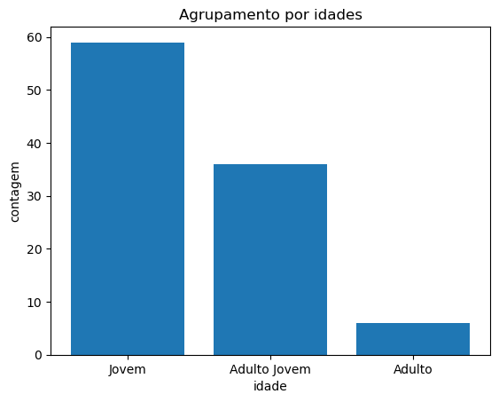

```python
plt.bar(group_names, df['idade_binned'].value_counts())
plt.xlabel("idade")
plt.ylabel('contagem')
plt.title("Agrupamento por idades")
```

Sendo assim, vamos verificar algumas medidas estatísticas para essa coluna e criar um agrupamento baseado nos dados ali contidos:

```python
df[['idade']].describe()
```

|  | idade |
| --- | --- |
| count | 101.000000 |
| mean | 20.530000 |
| std | 2.483767 |
| min | 18.000000 |
| 25% | 18.000000 |
| 50% | 19.000000 |
| 75% | 23.000000 |
| max | 24.000000 |

Com base nas estatísticas descritivas da coluna "idade", que foram obtidas usando o método describe(), observamos que o intervalo de idades no conjunto de dados varia de 18(min) a 24(max) anos. Aqui está a explicação de como escolhemos realizar o agrupamento:

- Mínimo e Máximo: O valor mínimo de idade é 18 anos, e o valor máximo é 24 anos. Escolhemos utilizar esses valores para definir os limites dos intervalos de agrupamento.
- Intervalos Significativos: Optamos por criar dois grupos com intervalos significativos. O primeiro grupo inclui idades de 18 a 20 anos enquanto o segundo grupo abrange idades de 20 a 23 anos.

Essa escolha de agrupamento visa criar categorias distintas que possam ser visualizadas representando as diferentes faixas etárias selecionadas.

```python
# Use describe para obter estatísticas descritivas
estatisticas_descritivas = df['idade'].describe()

# Defina os rótulos dos grupos
group_names = ['18-20', '20-23']

# Aplica o binning usando intervalos específicos na coluna 'idade' e cria uma nova coluna 'idade_binned'
df['idade_binned_1'] = pd.cut(df['idade'], bins=[18, 20, 23], labels=group_names, include_lowest=True)
```

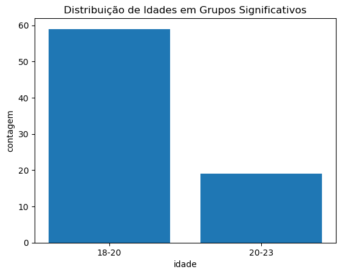

```python
plt.bar(group_names, df['idade_binned_1'].value_counts())
plt.xlabel("idade")
plt.ylabel('contagem')
plt.title("Distribuição de Idades em Grupos Significativos")
```

Por que realizar esse tipo de agrupamento?

Considere o último gráfico apresentado e suponha que, ao obter o conjunto de dados, já tenhamos a informação prévia de que alunos com idades entre 18 e 20 anos (incluindo essas faixas etárias) têm uma propensão maior a frequentar a biblioteca. No entanto, ao observar o número total de alunos no conjunto de dados, não conseguimos avaliar se esse grupo é significativamente grande ou pequeno em relação ao total. Ao realizar o agrupamento e visualizar o gráfico, torna-se evidente que o intervalo de idades (18-20) é mais de duas vezes maior que o outro grupo, proporcionando uma perspectiva mais clara da distribuição etária dos alunos e destacando a relevância do agrupamento para identificar diferenças significativas entre as faixas etárias.

Em cenários mais complexos, obviamente, devem ser realizadas outras considerações; mas para nossos fins, temos aqui mais do que adequadas e suficientes.

# 5 - Conversão de Dados Categóricos

À medida que continuamos a nos aprofundar na manipulação e preparação de dados, exploraremos agora a conversão de variáveis categóricas em indicadores, essa etapa visa tornar essas variáveis acessíveis aos algoritmos de aprendizado de máquina. É um passo que amplia a gama de técnicas analíticas as quais podemos aplicar de maneira robusta ao nosso conjunto de dados, contribuindo para nossa missão de compreender e obter informações dos dados brutos.

**Motivação**:

- A conversão de variáveis categóricas em indicadores garante que as variáveis estejam no formato adequado.
- Escolher os tipos de dados corretos não apenas otimiza o desempenho computacional, mas também facilita operações matemáticas e contribui para uma interpretação mais clara das variáveis.

**Implicações**:

- A falta de conversão pode resultar em inconsistências nos resultados, comprometendo a confiabilidade das análises.
- A padronização dos tipos de dados facilita a interpretação e execução de operações específicas, aprimorando a eficácia das análises.

A seguir, exploraremos a conversão de tipos em nosso conjunto de dados, utilizando como exemplo prático a coluna `tem_depressao`. Destacaremos a importância dessa etapa no processo de manipulação e análise, exemplificando como essa transformação contribui para a compreensão e utilidade dos dados. Vamos analisar essa coluna e determinar a melhor abordagem no processo.

Enquanto nos deparamos com diferentes tipos de variáveis ao longo deste projeto, é essencial abordar a questão das variáveis categóricas, que assumem valores qualitativos. Nossa atenção se volta agora à coluna "tem_depressao", uma variável binária que reflete se um aluno tem ou não depressão. Optamos por esta coluna por sua natureza binária (YES, NO) e por ser uma representação comum em muitos conjuntos de dados.

A tarefa atual nos direciona a converter a coluna "tem_depressao" em duas variáveis indicadoras distintas: "tem_depressao_Yes" e "tem_depressao_No". Essa operação não apenas otimizará a representação desses dados, mas também servirá como exemplo prático e educativo sobre como essa conversão pode ser aplicada em outras variáveis semelhantes.

Ao final dessa etapa, poderemos avaliar como essa transformação impacta nossa visão sobre o conjunto de dados, contribuindo para a evolução contínua da análise. Vamos agora explorar essa conversão.

```python
# Cria os indicadores
dummy_variable = pd.get_dummies(df['tem_depressao'], prefix='tem_depressao')

# Concatena os indicadores ao DataFrame original
df = pd.concat([df, dummy_variable], axis=1)

df.head(1)
```

|  | momento_envio | genero | idade | curso | ano_estudo_atual | cgpa | estado_civil | tem_depressao | tem_ansiedade | tem_ataque_panic | ... | altura_cm | peso_padronizado | altura_padronizada | idade_normalizada | peso_normalizado | altura_normalizada | idade_binned | idade_binned_1 | tem_depressao_No | tem_depressao_Yes |
| --- | --- | --- | --- | --- | --- | --- | --- | --- | --- | --- | --- | --- | --- | --- | --- | --- | --- | --- | --- | --- | --- |
| 0 | NaT | Female | 18.0 | Engineering | year 1 | 3.245 | No | Yes | No | Yes | ... | 188 | 1.667306 | 1.667306 | 0.0 | 0.974359 | 0.974359 | Jovem | 18-20 | 0 | 1 |

1 rows × 22 columns

Agora temos mais duas colunas "tem_depressao_No" e "tem_depressao_Yes" com valores booleanos.

**Utilização dos Indicadores:**

Os indicadores gerados, representados pelas colunas "tem_depressao_No" e "tem_depressao_Yes", terão serventia para a modelagem e análise de dados em contextos nos quais variáveis categóricas binárias sejam relevantes. Essa transformação permite uma integração mais eficaz com algoritmos de aprendizado de máquina, que muitas vezes requerem a representação numérica de variáveis.

Aqui estão algumas maneiras pelas quais esses indicadores podem ser aplicados:

**1. Modelagem Preditiva:**

- Algoritmos de machine learning, como regressão logística ou árvores de decisão, geralmente exigem variáveis binárias como entrada. Esses indicadores fornecem uma representação adequada para o atributo "tem_depressao", permitindo a aplicação eficiente desses algoritmos.

**2. Análise Exploratória:**

- Facilitam a visualização e interpretação dos dados. Por exemplo, podemos analisar a distribuição de estudantes que têm ou não depressão em diferentes categorias, explorando padrões e tendências. Como exemplo ilustrativo, vamos supor que temos uma coluna adicional chamada "desempenho_academico" com valores como "Bom" e "Ruim". Podemos agora explorar como o desempenho acadêmico está relacionado à presença ou ausência de depressão.

**3. Comparação e Filtragem:**

- Permite comparações diretas entre grupos de estudantes com e sem depressão. Isso é útil para entender como diferentes fatores podem estar relacionados à condição de saúde mental.

**Generalização para Outras Variáveis:**

Esse processo de conversão para indicadores pode ser estendido a outras variáveis categóricas binárias do conjunto de dados, oferecendo uma abordagem consistente e eficaz em sua preparação a fim de que possamos realizar análises mais avançadas.

Ao reconhecer a importância dessa etapa e compreender sua aplicabilidade, garantimos que nossos dados estejam prontos para serem utilizados em aplicações analíticas robustas. Esse fato contribui para realizações de análises mais abrangentes e precisas.

# 6 - Considerações finais

Ao finalizar este projeto educativo de Análise de Dados, celebramos não apenas a conclusão de tarefas específicas; mas, mais significativamente, a aquisição de conhecimentos fundamentais que formam a base sólida para a manipulação e interpretação de dados. Durante o processo exploramos de maneira prática, bem como nos aprofundamos em conceitos apresentados na segunda semana do curso "Data Analysis with Python" da Coursera.

A abordagem adotada destacou a importância da compreensão profunda de cada passo percorrido na análise de dados, não nos limitamos apenas a realizar tarefas, mas dedicamo-nos a compreender os motivos subjacentes a cada decisão tomada. Essa abordagem reflexiva não apenas fortalece nossa capacidade de aplicar técnicas específicas, mas também nos capacita a enfrentar desafios inesperados de forma mais eficaz.

Ao concluirmos este projeto, muito além de celebrarmos habilidades adquiridas, lançamo-nos em direção ao futuro; e agora, equipados não apenas com técnicas específicas, mas também com uma compreensão um pouco mais profunda e sólida dos princípios que sustentam tais técnicas.

O aprendizado contínuo e a aplicação prática desses conhecimentos em cenários do mundo real serão a chave para a evolução constante como profissionais de análise de dados.

Em resumo, este projeto não é apenas uma conclusão, mas sim o início de uma jornada mais ampla. Que possamos continuar com nossa busca, aprendendo e aplicando nossos conhecimentos para impulsionar a inovação e a compreensão em nossa comunidade e além.

# 7 - Apêndice

## 7.1 - Compreendendo a Semente de Aleatoriedade (Seed)

Em ciência de dados, pode-se fazer necessária a geração de números aleatórios, no entanto, para garantir consistência nos resultados entre diferentes execuções de um código, fazemos uso da semente de aleatoriedade (seed).

*Analogia com Caixas e Bolas:*

Vamos imaginar que temos várias caixas, cada uma contendo uma fila única de bolas coloridas. Cada vez que retiramos uma bola, a ordem é determinada pela própria caixa. Aqui, as caixas representam diferentes sequências pseudoaleatórias.

A semente de aleatoriedade é como escolher uma caixa específica para começar. Se escolhermos a mesma caixa (mesma semente) toda vez, retiraremos as bolas na mesma ordem, como se elas estivessem pacientemente alinhadas na fila, esperando para serem retiradas.

*Exemplo Prático:*

Consideremos duas caixas:

- Caixa 1 (Semente = 1): Bolas azul, verde, roxa.
- Caixa 2 (Semente = 2): Bolas roxa, azul, verde.

Se optarmos pela caixa 1 (seed = 1) `np.random.seed(1)`, retiraremos as bolas na sequência azul, verde, roxa. Se outra pessoa escolher a mesma caixa 1, ela também retirará as bolas na mesma ordem predefinida. De maneira análoga, se optarmos pela caixa 2 (seed = 2) `np.random.seed(2)`, a sequência será roxa, azul, verde, e qualquer pessoa que escolher a caixa 2 retirará a mesma sequência predefinida.

A semente de aleatoriedade (np.random.seed(1)) proporciona consistência, como se as bolas estivessem sempre dispostas em uma fila, aguardando serem retiradas na mesma ordem, independentemente de quem as estiver retirando.

Essa abordagem assegura a reprodutibilidade dos resultados, ou seja, não importa quem for "executar" a tabela que criamos, os resultados obtidos serão sempre os mesmos; o que nos proporciona uma base sólida para análises comparáveis e reproduzíveis.

## 7.2 - Decisão sobre Colunas pós Padronização - Manter ou Remover?

### 7.2.1 Manter as Colunas Originais:

**Interpretação Intuitiva:**

- Se a interpretação direta dos valores originais (não padronizados) for mais relevante para o público-alvo, pode ser útil manter as colunas originais.

**Visualização:**

- Em algumas visualizações, é mais natural trabalhar com os dados em suas escalas originais. Manter as colunas originais facilita a criação de gráficos compreensíveis.

### 7.2.2 Remover as Colunas Originais:

**Economia de Espaço:**

- Se a economia de espaço ou a simplificação do conjunto de dados forem prioridades, remover as colunas originais após a padronização pode ser benéfico.
- Prevenção de Redundância: Em alguns casos, manter as colunas originais pode ser redundante, especialmente se todas as análises subsequentes forem baseadas nos dados padronizados.

### 7.3 Abordagem Híbrida:

**Escolha Seletiva:**

- Pode-se optar por manter apenas as colunas padronizadas ou, em um contexto exploratório, manter ambas as versões para uma análise comparativa.

Em última análise, a decisão dependerá da natureza do seu projeto, dos requisitos de apresentação e das preferências específicas.

## 7.4 Mais algumas palavras sobre Normalização

A normalização é frequentemente utilizada ao preparar dados para algoritmos de aprendizado de máquina. Aqui estão algumas razões pelas quais esse processo é enfatizado:

- **Escalas Comparáveis:** Algoritmos que utilizam medidas de distância, podem ser influenciados pela escala dos dados. A normalização coloca todas as variáveis em uma escala comparável, evitando que uma variável com uma escala maior domine a influência nos resultados.
- **Convergência mais Rápida:** Algoritmos de otimização, como aqueles usados em redes neurais, geralmente convergem mais rápido em dados normalizados. Isso pode levar a um treinamento mais eficiente do modelo.
- **Influência do Outlier Mitigada:** A normalização ajuda a reduzir a influência de valores discrepantes (outliers) ao colocar todos os dados em uma escala mais uniforme.
- **Interpretação Mais Intuitiva:** Quando os dados estão normalizados, a interpretação dos coeficientes ou pesos do modelo torna-se mais intuitiva, pois as variáveis estão em escalas comparáveis.
- **Preparação de Dados para Algoritmos Específicos:** Alguns algoritmos, como redes neurais, são sensíveis à escala dos dados. Normalizar os dados ajuda a criar uma entrada mais apropriada para esses algoritmos.

Sugerimos uma pesquisa aprofundada caso o leitor deseje saber mais detalhes do que foi dito acima

## 7.5 Considerações sobre Binning

Antes de realizar o agrupamento (binning), precisamos determinar a faixa intervalar apropriada para a variável a ser analisada. A escolha da faixa intervalar afeta diretamente a interpretação dos dados e a eficácia do agrupamento.

Aqui estão algumas considerações ao determinar a faixa intervalar:

- **Entendimento do Domínio:** É necessário conhecer o contexto do problema e entender a natureza da variável. Por exemplo, ao agrupar idades, pode ser interessante escolher intervalos significativos, como faixas etárias comuns (por exemplo, 0-18, 19-35, 36-50, etc.).
- **Distribuição dos Dados:** Se os dados estão concentrados em uma faixa estreita, pode ser útil escolher intervalos menores para capturar detalhes específicos. Se os dados são mais dispersos, intervalos maiores podem ser mais apropriados.
- **Objetivos Analíticos:** Considere os objetivos específicos da análise. Às vezes, intervalos mais amplos são escolhidos para fornecer uma visão geral, enquanto intervalos menores podem ser necessários para análises mais detalhadas.
- **Relevância para o Público-alvo:** Pense no público-alvo da análise. Intervalos significativos e compreensíveis para o público tornam a interpretação mais acessível.

Antes de implementar o agrupamento, realizar uma análise exploratória dos dados pode ajudar a informar a escolha da faixa intervalar mais apropriada, no entanto, esse aspecto não está contido no objetivo desse projeto.